# Notebook 17

## 1. Bayesian Estimator for Binomial Probability

Following the class notes, here is a visualization of the posterior probability for the estimation of the proportion p from a binomial sample. You can play around with the values of the sample size (N) and the count of 1s (X), watching how the posterior changes.

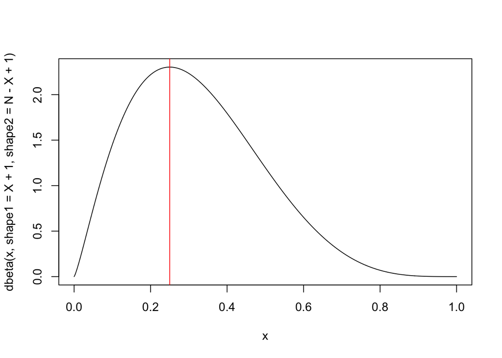

```r
N <- 5
X <- N * (0.25)
curve(dbeta(x, shape1 = X + 1, shape2 = N - X + 1),
      from = 0, to = 1, cex = 2, n = 1000)
abline(v = X / N, col = "red")
```

You should see that as N grows, the probability distribution begins to move from a uniform distribution (the prior) to a distribution concentrated on the mean.

## 2. Credible Region

Let’s create an actual sample of data from a hypothetical binomial distribution, where 25% of data are equal to 1 and 75% of the data are equal to 0.

```r
N <- 100
x <- rep(c(0, 1), c(N * (1-0.25), N * (0.25)))
x
```

```
##   [1] 0 0 0 0 0 0 0 0 0 0 0 0 0 0 0 0 0 0 0 0 0 0 0 0 0 0 0 0 0 0 0 0 0 0 0
##  [36] 0 0 0 0 0 0 0 0 0 0 0 0 0 0 0 0 0 0 0 0 0 0 0 0 0 0 0 0 0 0 0 0 0 0 0
##  [71] 0 0 0 0 0 1 1 1 1 1 1 1 1 1 1 1 1 1 1 1 1 1 1 1 1 1 1 1 1 1
```

The T-test function, as we know, can give a confidence interval based on the T pivot statistic:

```r
t.test(x)
```

```
##
##  One Sample t-test
##
## data:  x
## t = 5.7446, df = 99, p-value = 1.017e-07
## alternative hypothesis: true mean is not equal to 0
## 95 percent confidence interval:
##  0.163648 0.336352
## sample estimates:
## mean of x
##      0.25
```

We can, alternatively, use our Bayesian approach to find a credible region for the value p:

```r
X <- sum(x)
cint <- c(
  qbeta(0.05/2, shape1 = X + 1, shape2 = N - X + 1),
  qbeta(1 - 0.05/2, shape1 = X + 1, shape2 = N - X + 1)
)
sprintf("95%% Confidence Interval: p ∈ [%.03f, %.03f]", cint[1], cint[2])
```

```
## [1] "95% Confidence Interval: p ∈ [0.176, 0.343]"
```

Notice that the value is very similar to the one based on the T-test. The biggest advantage is that we have a much less complex way of describing the interpretation of the credible interval.